# Using Rcpp to speed up non-parametric estimation in R

Andreï V. Kostyrka, University of Luxembourg

Created: 2023-12-05, last modified: 2024-01-15, compiled: 2025-10-28

Abstract

This vignette demonstrates how to carry out non-parametric density and kernel estimation with a high degree of flexibility and greater speed than via the straightforward textbook approach.

```r
library(smoothemplik)

clock <- function(expr, n = 20) {
  # Capturing the output into the warm-up iteration to retuce the timing
  # overhead from spinning up the processor from any sleep or idle state
  # (idea from the microbenchmark package)
  ret <- expr
  tic0 <- proc.time()
  replicate(n, suppressWarnings(suppressMessages(expr)))
  tm <- proc.time() - tic0
  et <- as.numeric(tm["elapsed"]) * 1000
  times <- c(median = et, mean = mean(et), sd = sd(et))
  ftimes <- ifelse(times > 1, sprintf("%1.1f", times),
                   ifelse(times == 1, "~0.5-1.5", "<0.5"))
  ftimes[3] <- sprintf("%1.1f", times[3])
  cat("Median [mean +- SD] time per evaluation: ", ftimes[1], " [",
      ftimes[2], "+-",  "]", " ms\n", sep = "")
  attr(ret, "time") <- times
  return(ret)
}

quiet <- function(expr) {  # Suppressing all output
  sink(if (.Platform$OS.type == "windows") "NUL" else "/dev/null")
  ret <- expr
  sink()
  return(ret)
}
```

## 1 Kernel methods

Implementing kernel weights, kernel density estimation, and locally constant kernel regression in **R** is straightforward.

Kernel weights define a local neighbourhood for a point using the value of the kernel function:
$$w_{ij} := k\left( \frac{X_i - X_j}{b} \right),$$
where $k$ is a function that typically satisfies these properties:

1. Symmetry: $k(-u) = k(u)$, $u\in \mathbb{R}$;
2. Unit integral over the reals: $\int_{\mathbb{R}} k = 1$;
3. Second order: $\int_{\mathbb{R}} u^2 k(u) \in (0, \infty)$.

All of these properties can be relaxed. Asymmetrical kernels are sometimes used to improve kernel density estimates (KDE) when the data support is bounded. The unit integral simplifies calculations and formulæ for densities owing to its built-in normalisation. Finally, higher-order kernels reduce bias but may introduce negative values of $k(u)$, which can necessary in some applications (e.,g. Robinson (1988) semi-parametric regression with more than 5 non-parametric regressors), but undesirable in others, such as density estimation.

The `smoothemplik` package implements the following kernel functions:

Kernel weights $w_{ij}$ do not sum to unity and can be used `as is’ for most applications to represent relative importance. For density and regression applications, re-scaled weights are necessary.

Multi-variate kernels are defined similarly. For simplicity, we restrict our scope to product kernels and re-define kernel weights accordingly:
$$w_{ij} := \prod_{l=1}^d k\left( \frac{X_i^{(l)} - X_j^{(l)}}{b^{(l)}}
\right) := K\left( \frac{X_i - X_j}{b} \right),$$
where $d = \dim X$ is the number of variables and $b$ is a vector of bandwidths with $\dim b = d$.

In certain applications, where the evaluation grid coincides with the support of $X$, the number of computations can be halved due to the symmetry of the kernel function. In most cases, the grid of evaluation points for non-parametric methods is pre-defined, yielding a non-square weight matrix.

Univariate kernel weights:

```r
# x = numeric vector, xout = numeric vector, bw = scalar, kfun = function
kernelWeights1R <- function(x, xout, bw, kfun) kfun(outer(xout, x, "-") / bw)
```

For demonstration, we skip type and length checks to highlight the `Rcpp` solution superiority. In this vignette, we use inputs for the benchmark functions that need no sanitisation. The hidden function `smoothemplik:::.prepareKernel` handles these checks before calling the C++ function.

```r
kernelWeightsR <- function(x, xout = NULL, bw = 1, kfun = stats::dnorm) {
  if (is.null(dim(x))) x <- as.matrix(x)
  if (is.null(xout)) xout <- x
  if (is.null(dim(xout))) xout <- as.matrix(xout)
  d <- ncol(x)
  if (d > 1 && length(bw) == 1) bw <- rep(bw, d)
  pk <- kernelWeights1R(x = x[, 1], xout = xout[, 1], bw = bw[1], kfun = kfun)
  if (d > 1) { # Accumulating the product kernel
    for (i in 2:d)
      pk <- pk * kernelWeights1R(x = x[, i], xout = xout[, i], bw = bw[i], kfun = kfun)
  }
  return(pk)
}
```

The Parzen–Rosenblatt density estimator is a rescaled sum of the kernel functions:
$$\hat f_X(x) := \frac{1}{nb^{(1)} \cdots b^{(d)}} \sum_{i=1}^n K\left(
\frac{X_i - x}{b} \right)$$

```r
kernelDensityR <- function(x, xout = NULL, bw = 1, kfun = stats::dnorm) {
  x1d <- is.null(dim(x))
  n <- if (x1d) length(x) else nrow(x)
  if (isTRUE(ncol(x) > 1) && length(bw) == 1) bw <- rep(bw, ncol(x))
  pk <- kernelWeightsR(x = x, xout = xout, bw = bw, kfun = kfun)
  return(rowSums(pk) / (n * prod(bw)))
}
```

The Nadaraya–Watson regression function estimator a local (weighted) average:
$$\hat m(x) = \hat{\mathbb{E}}(Y \mid X = x) := \frac{\sum_{i=1}^n Y_i
K((X_i - x)/b)}{\sum_{i=1}^n K((X_i - x)/b)}$$

For optimal bandwidth calculation, quite often, a Leave-One-One (LOO) variety is used:
$$\hat m_{-i}(x) := \frac{\sum_{j\ne i} Y_j K((X_j - x)/b)}{\sum_{j\ne i}
K((X_j - x)/b)}$$
It can be implemented by setting the weight of the $i$^th observation to zero.

The LOO estimator makes sense only on a grid of original observed points $\{X_i\}_{i=1}^n$ or its subset.

```r
kernelSmoothR <- function(x, y, xout = NULL, bw = 1,
                          kfun = stats::dnorm, LOO = FALSE) {
  pk <- kernelWeightsR(x = x, xout = xout, bw = bw, kfun = kfun)
  if (LOO) diag(pk) <- 0
  return(rowSums(sweep(pk, 2, y, "*")) / rowSums(pk))
}
```

### 1.1 Speed-ups

The `smoothemplik` package incorporates multiple optimisations that make non-parametric estimation less demanding in terms of computational power.

1. **RcppArmadillo integration.** The core of the package is built on `RcppArmadillo` for fast vector and matrix manipulations.
2. **In-place calculations.** All kernel calculations are performed in place to save memory. No extra vectors are initialised; instead, the return vector is created at the beginning and modified based on the chosen kernel. For example, `ax = abs(x)` is modified directly: `if (ax[i] < 1) ax[i] = 0.75*(1 - ax[i]^2)`, and `ax` itself is returned at the end. Similarly, The Nadaraya–Watson numerator is computed in place from the weight matrix, ensuring that there is only one large matrix in the memory.
3. **TODO:** Memory-saving of `kernelWeights` through sparse matrices
4. **Bandwidth scaling.** Following Equation 4.4 in Silverman (1986), we perform bandwidth scaling $\frac{X_i-x}{b} = \frac{X_i}{b}-\frac{x}{b} = X^*_i - x^*$. This reduces the number or arithmetic operations in the double loop. Scaling factors in the form $\frac{1}{nb^{(1)} \cdots b^{(d)}}$ are also applied after the final vector or kernel sums is obtained.
5. **Faster higher-order kernels.** This package includes qualitatively different 4th-order kernels to reduce the polynomial degree of the convolution kernels. If a kernel has polynomial degree $p$, its 4th-order analogue in this package also has degree $p$, resulting in a convolution polynomial of degree at most $2p+1$. The traditional approach, as described in Section 1.11 of Li and Racine (2007), adds an extra polynomial. For instance, the 4th-order version of the the Epanechnikov kernel has a degree of 4, leading to a convolution degree $4\cdot 2 + 1 = 9$. However, a version consisting of piecewise quadratic polynomials can achieve a degree of 2 and a convolution degree of 5, retaining the smoothness properties of the original Epanechnikov kernel.

The vignette illustrating the last point about faster higher-order kernels is in progress.

## 2 Univariate kernel estimation

```r
set.seed(1)
X <- sort(rchisq(300, 3))
xg <- seq(0, max(X), length.out = 100)
Y <- sin(X) + rnorm(300)
b <- 0.5
```

Now, we compare the pure R and Rcpp functions:

```r
wCPP <- clock(kernelWeights(X, xout = xg, bw = b))
```

```
#> Median [mean +- SD] time per evaluation: 4.0 [4.0+-] ms
```

```r
wR   <- clock(kernelWeightsR(X, xout = xg, bw = b))
```

```
#> Median [mean +- SD] time per evaluation: 4.0 [4.0+-] ms
```

```r
fCPP <- clock(kernelDensity(X, xout = xg, bw = b))
```

```
#> Median [mean +- SD] time per evaluation: <0.5 [<0.5+-] ms
```

```r
fR   <- clock(kernelDensityR(X, xout = xg, bw = b))
```

```
#> Median [mean +- SD] time per evaluation: <0.5 [<0.5+-] ms
```

```r
mCPP <- clock(kernelSmooth(X, Y, xout = xg, bw = b))
```

```
#> Median [mean +- SD] time per evaluation: <0.5 [<0.5+-] ms
```

```r
mR   <- clock(kernelSmoothR(X, Y, xout = xg, bw = b))
```

```
#> Median [mean +- SD] time per evaluation: <0.5 [<0.5+-] ms
```

Note that there are tiny discrepancies related to the order of operations and finite machine precision:

```r
all.equal(wR, wCPP, tolerance = 1e-16)
```

```
#> [1] "Attributes: < Component \"time\": Mean relative difference: 2.220446e-13 >"
#> [2] "Mean relative difference: 1.725457e-10"
```

```r
all.equal(fR, fCPP, tolerance = 1e-16)
```

```
#> [1] "Attributes: < Names: 1 string mismatch >"
#> [2] "Attributes: < Length mismatch: comparison on first 1 components >"
#> [3] "Attributes: < Component 1: Names: 3 string mismatches >"
#> [4] "Attributes: < Component 1: Numeric: lengths (3, 5) differ >"
#> [5] "Mean relative difference: 4.758193e-16"
```

```r
all.equal(mR, mCPP, tolerance = 1e-16)
```

```
#> [1] "Attributes: < Names: 1 string mismatch >"
#> [2] "Attributes: < Length mismatch: comparison on first 1 components >"
#> [3] "Attributes: < Component 1: names for target but not for current >"
#> [4] "Attributes: < Component 1: Numeric: lengths (3, 0) differ >"
#> [5] "Mean relative difference: 8.732475e-16"
```

We can visualise the results and see that the discrepancies are tiny:

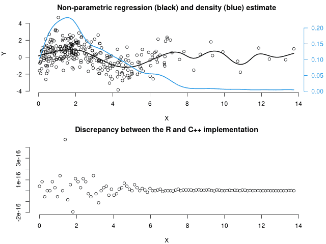

```r
oldpar <- par(mfrow = c(2, 1), mar = c(4, 4, 2, 3))
plot(X, Y, bty = "n", main = "Non-parametric regression (black) and density (blue) estimate", las = 1)
lines(xg, mCPP, lwd = 2)
par(new = TRUE)
plot(xg, fCPP, type = "l", lwd = 2, yaxt = "n", bty = "n", xaxt = "n", col = 4, xlab = "", ylab = "", las = 1)
axis(4, col = 4, col.axis = 4, las = 1)
plot(xg, fR - fCPP, bty = "n", ylab = "", xlab = "X",
     main = "Discrepancy between the R and C++ implementation")
```

Different kernel shapes can be used upon user request (all of them, except for the default Gaussian, have finite support on $[-1, 1]$):

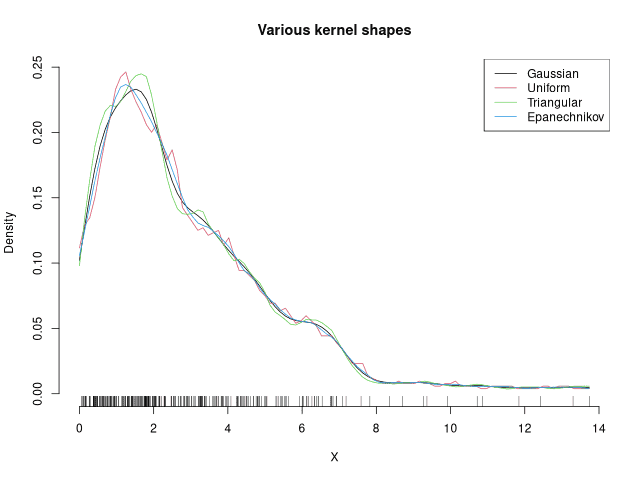

```r
par(mfrow = c(1, 1))
fCPPunif <- kernelDensity(X, xout = xg, bw = b * sqrt(3), kernel = "uniform")
fCPPtrng <- kernelDensity(X, xout = xg, bw = b * sqrt(3), kernel = "triangular")
fCPPepan <- kernelDensity(X, xout = xg, bw = b * sqrt(5), kernel = "epanechnikov")
plot(xg, fCPP, ylim = range(0, fCPP, fCPPunif, fCPPtrng, fCPPepan), xlab = "X",
     type = "l", bty = "n", main = "Various kernel shapes", ylab = "Density")
rug(X)
lines(xg, fCPPunif, col = 2)
lines(xg, fCPPtrng, col = 3)
lines(xg, fCPPepan, col = 4)
legend("topright", c("Gaussian", "Uniform", "Triangular", "Epanechnikov"), lwd = 1, col = 1:4)
```

The speed-up is more substantial with large data sets:

```r
ns <- c(500, 1000, 2000)
timings <- sapply(ns, function(n) {
  set.seed(1)
  X <- rchisq(n, 3)
  b <- bw.rot(X)
  tR <- quiet(clock(fR <- kernelDensityR(X, bw = b), n = 3))
  tCPP <- quiet(clock(fCPP <- kernelDensity(X, bw = b), n = 3))
  c(R = attr(tR, "time"), CPP = attr(tCPP, "time"))
})
colnames(timings) <- paste0("n=", ns)
print(timings, 2)
```

```
#>            n=500 n=1000 n=2000
#> R.median       0      0      1
#> R.mean         0      0      1
#> R.sd          NA     NA     NA
#> CPP.median     0      0      0
#> CPP.mean       0      0      0
#> CPP.sd        NA     NA     NA
```

## 3 Multivariate kernel estimation

```r
set.seed(1)
n <- 100
ng <- 30
X <- matrix(rchisq(n*2, 3), ncol = 2)
xg0 <- seq(0, 13, length.out = ng)
xg <- expand.grid(X1 = xg0, X2 = xg0)
Y <- sin(X[, 1]) + sin(X[, 2]) + rnorm(n)
b <- c(0.7, 0.8)

wCPP <- clock(kernelWeights(X, xout = xg, bw = b), n = 10)
```

```
#> Median [mean +- SD] time per evaluation: 11.0 [11.0+-] ms
```

```r
wR <- clock(kernelWeightsR(X, xout = xg, bw = b), n = 10)
```

```
#> Median [mean +- SD] time per evaluation: 11.0 [11.0+-] ms
```

```r
all.equal(wR, wCPP, tolerance = 1e-16)
```

```
#> [1] "Mean relative difference: 1.066705e-15"
```

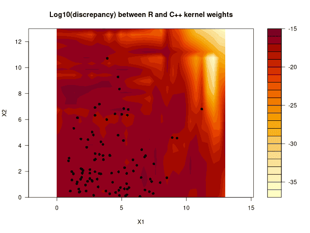

```r
max.dw <- apply(wR - wCPP, 1, function(x) max(abs(x), na.rm = TRUE))
filled.contour(xg0, xg0, log10(matrix(max.dw, ng, ng)), xlab = "X1", ylab = "X2",
               main = "Log10(discrepancy) between R and C++ kernel weights", asp = 1)
points(X[, 1], X[, 2], pch = 16)
```

We redo the same test for the kernel density estimator:

```r
fCPP <- clock(kernelDensity(X, xout = xg, bw = b), n = 5)
```

```
#> Median [mean +- SD] time per evaluation: <0.5 [<0.5+-] ms
```

```r
fR <- clock(kernelDensityR(X, xout = xg, bw = b), n = 5)
```

```
#> Median [mean +- SD] time per evaluation: <0.5 [<0.5+-] ms
```

```r
all.equal(fR, fCPP, tolerance = 1e-16)
```

```
#> [1] "Attributes: < Names: 1 string mismatch >"
#> [2] "Attributes: < Length mismatch: comparison on first 1 components >"
#> [3] "Attributes: < Component 1: Names: 3 string mismatches >"
#> [4] "Attributes: < Component 1: Numeric: lengths (3, 5) differ >"
#> [5] "Mean relative difference: 3.943699e-16"
```

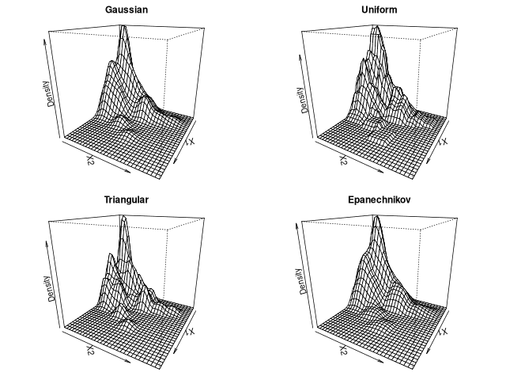

```r
fCPPunif <- kernelDensity(X, xout = xg, bw = b * sqrt(3), kernel = "uniform")
fCPPtrng <- kernelDensity(X, xout = xg, bw = b * sqrt(3), kernel = "triangular")
fCPPepan <- kernelDensity(X, xout = xg, bw = b * sqrt(5), kernel = "epanechnikov")
par(mfrow = c(2, 2), mar = c(0.5, 0.5, 2, 0.5))
persp(xg0, xg0, matrix(fCPP, nrow = ng), theta = 120, phi = 20, main = "Gaussian", xlab = "X1", ylab = "X2", zlab = "Density")
persp(xg0, xg0, matrix(fCPPunif, nrow = ng), theta = 120, phi = 20, main = "Uniform", xlab = "X1", ylab = "X2", zlab = "Density")
persp(xg0, xg0, matrix(fCPPtrng, nrow = ng), theta = 120, phi = 20, main = "Triangular", xlab = "X1", ylab = "X2", zlab = "Density")
persp(xg0, xg0, matrix(fCPPepan, nrow = ng), theta = 120, phi = 20, main = "Epanechnikov", xlab = "X1", ylab = "X2", zlab = "Density")
```

Now, we run a quick benchmark to see how the problem scales with the sample size and the dimension of the data. These evaluations take longer, so we use the built-in `system.time()` because the CPU overhead is negligible:

```r
ns <- c(125, 500)
dims <- c(2, 6)
nd <- expand.grid(n = ns, dim = dims)

timings <- t(sapply(seq_len(nrow(nd)), function(i) {
  set.seed(1)
  X <- matrix(rchisq(nd$n[i] * nd$dim[i], 3))
  b <- bw.rot(X)
  aR <- system.time(kernelDensityR(X, bw = b))["elapsed"]
  aCPP <- system.time(kernelDensity(X, bw = b))["elapsed"]
  c(R = aR, CPP = aCPP)
}))
timings <- cbind(nd, timings)
print(timings, 2)
```

```
#>     n dim R.elapsed CPP.elapsed
#> 1 125   2     0.003       0.003
#> 2 500   2     0.043       0.013
#> 3 125   6     0.024       0.009
#> 4 500   6     0.800       0.103
```

Finally, we can visualise the kernel regression estimator with various kernels and degrees, and robustness operations (described in Cleveland (1979)). Since the true functional dependence of $Y$ on $X$ is a sine wave, we expect the second-degree local estimator to perform the best.

Here, instead of choosing the bandwidth using the rule of thumb, we plot the cross-validation function (assuming that the bandwidth should be the same across all dimensions):

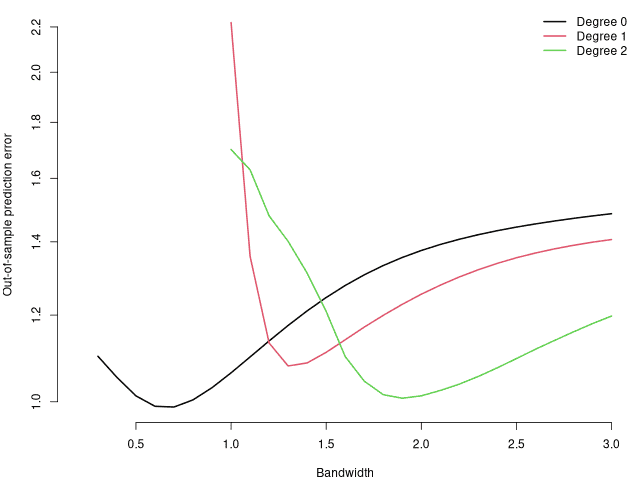

```r
bwgrid <- seq(0.2, 3, .1)
bws0 <- suppressWarnings(LSCV(X, Y, bw = bwgrid, degree = 0, same = TRUE))
bws1 <- suppressWarnings(LSCV(X, Y, bw = bwgrid, degree = 1, same = TRUE))
bws2 <- suppressWarnings(LSCV(X, Y, bw = bwgrid, degree = 2, same = TRUE))
bw.cv <- cbind(bws0, bws1, bws2)
bw.opt <- bwgrid[apply(bw.cv, 2, which.min)]
par(mar = c(4, 4, 0.5, 0.5))
matplot(bwgrid, bw.cv, lty = 1, type = "l", bty = "n", lwd = 2, col = 1:3,
        xlab = "Bandwidth", ylab = "Out-of-sample prediction error", log = "y")
legend("topright", paste("Degree", 0:2), lwd = 2, lty = 1, col = 1:3, bty = "n")
```

To avoid the low-density region, we focus on a smaller range of regressor values, $[0, 8]$:

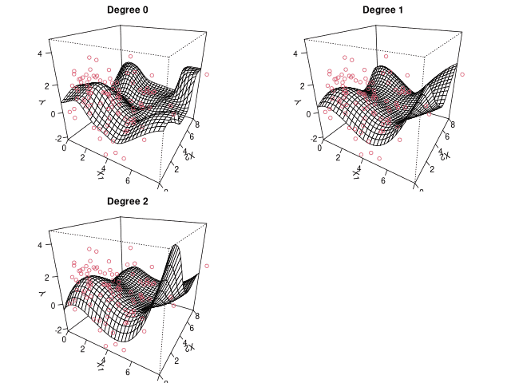

```r
xg0 <- seq(0, 8, length.out = ng)
xg <- expand.grid(X1 = xg0, X2 = xg0)
yhat <- sapply(1:3, function(i) kernelSmooth(x = X,  y = Y, xout = xg, bw = bw.opt[i], degree = i-1))
par(mfrow = c(2, 2), mar = c(0.2, 0.2, 2, 0.2))
for (i in 1:3) {
  p <- persp(xg0, xg0, matrix(yhat[, i], ng, ng), ticktype = "detailed",
             main = paste0("Degree ", i-1), theta = 30, phi = 25,
             xlab = "X1", ylab = "X2", zlab = "Y", zlim = range(yhat, Y))
  points(trans3d(X[, 1], X[, 2], Y, p), col = 2)
}
```

We can judge the fit quality by the percentage of explained variance (the issue of over-fitting with small bandwidths has been mitigated via cross-validation) using the available observations as the grid. This comparison is valid only because the noise is homoskedastic in this simulation, which makes the unconditional error variance interpretable. In real-life applications, consider other quality-of-fit measures.

```r
ys <- sapply(1:3, function(i) kernelSmooth(x = X,  y = Y, bw = bw.opt[i], degree = i-1))
colnames(ys) <- paste("Degree", 0:2)
print(cor(cbind(Y, ys))[1, 2:4], 3)
```

```
#> Degree 0 Degree 1 Degree 2
#>    0.775    0.730    0.732
```

TODO: a vector of bandwidths (adaptive smoothing)

## 4 Sparsity

Large matrices of kernel weights with many zeros can be stored more efficiently using the facilities of the `Matrix` package that should be loaded automatically. E.g. it is not widely known that the computer version of the Gaussian kernel effectively has finite support in most evaluations. Indeed, $\log_2[\phi(8.62602) / \phi(0)] \approx 2^{-53.674} < \epsilon_{\mathrm{mach}} = 2^{-53}$, which means that the tail density at $\pm8.62603$ and beyond is indistinguishable from zero to the computer compared to the maximum value, i.e. `dnorm(0) + dnorm(8.62603) == dnorm(0)` is `TRUE`! Similarly, `1 + dnorm(8.46378) != 1` but `1 + dnorm(8.46379) == 1`, which is expected because `log2(dnorm(8.46379)) == -53.00001`, i.e. the ratio of the values is less than the machine epsilon, and the smaller value is zeroed out.

Therefore, a matrix with Gaussian weights should have some zeros in computer memory even though $\phi(x) > 0$ on $\mathbb{R}$:

```r
set.seed(1)
n <- 1000
X <- sort(rnorm(n))
w1 <- kernelWeights(X, bw = 0.1)
w2 <- kernelWeights(X, bw = 0.1, sparse = TRUE)
print(c(object.size(w1), object.size(w2)))
```

```
#> [1] 8000216 5167184
```

```r
print(c(class(w1)[1], class(w2)[1]))
```

```
#> [1] "matrix"    "dgCMatrix"
```

The savings are not always present – testing is needed:

```r
print(c(object.size(kernelWeights(X, bw = 0.5)),
        object.size(kernelWeights(X, bw = 0.5, sparse = TRUE))))
```

```
#> [1]  8000216 11950880
```

Using kernels with limited support explicitly increases the savings owing to sparsity:

```r
print(c(object.size(kernelWeights(X, kernel = "epanechnikov", bw = 0.6)),
        object.size(kernelWeights(X, kernel = "epanechnikov", bw = 0.6, sparse = TRUE))))
```

```
#> [1] 8000216 3832976
```

`smoothemplik` offers another storage format for sparse weight matrices: a list with indices of non-zero elements in each row and their values. Since the weights have to add up to one, by default, it re-normalises the rows to add up to unity, which is why `renormalise = FALSE` is required to preserve the original kernel weights.

```r
set.seed(1)
nz <- c(1, 1, 0, 0, 0, 1, 1, 0, 1, 1, 1, 0, 0, 0, 1, 1)
m <- matrix(runif(16) * nz, nrow = 4, byrow = TRUE)
print(m)
```

```
#>           [,1]       [,2]      [,3]      [,4]
#> [1,] 0.2655087 0.37212390 0.0000000 0.0000000
#> [2,] 0.0000000 0.89838968 0.9446753 0.0000000
#> [3,] 0.6291140 0.06178627 0.2059746 0.0000000
#> [4,] 0.0000000 0.00000000 0.7698414 0.4976992
```

```r
print(apply(m, 1, sparseVectorToList, renormalise = FALSE))
```

```
#> [[1]]
#> [[1]]$idx
#> [1] 1 2
#>
#> [[1]]$ct
#> [1] 0.2655087 0.3721239
#>
#>
#> [[2]]
#> [[2]]$idx
#> [1] 2 3
#>
#> [[2]]$ct
#> [1] 0.8983897 0.9446753
#>
#>
#> [[3]]
#> [[3]]$idx
#> [1] 1 2 3
#>
#> [[3]]$ct
#> [1] 0.62911404 0.06178627 0.20597457
#>
#>
#> [[4]]
#> [[4]]$idx
#> [1] 3 4
#>
#> [[4]]$ct
#> [1] 0.7698414 0.4976992
```

Not only the savings appear in large objects, the list of lists can be passed to `parallel::mclapply` for speed gains, and it does not need conversion back to numeric, unlike sparse matrices. Here is how it compares to the `dgCMatrix` solution: the size is slightly larger, but the large number of small row-based chunks can be handled immediately without accessing the entire matrix. This is useful in such applications as re-sampling, bootstrap, big-data handling etc.

```r
kw <- kernelWeights(X, kernel = "epanechnikov", bw = 0.6)
print(c(object.size(kw),
        object.size(kernelWeights(X, kernel = "epanechnikov", bw = 0.6, sparse = TRUE)),
        object.size(apply(kw, 1, sparseVectorToList, renormalise = FALSE))))
```

```
#> [1] 8000216 3832976 4285640
```

## 5 Conclusion

These examples showcase the speed improvements and comparable accuracy of the Rcpp implementations over pure R code, making the `smoothemplik` a versatile and efficient tool for non-parametric statistical analysis.

## 6 References

Cleveland, William S. 1979. “Robust Locally Weighted Regression and Smoothing Scatterplots.” *Journal of the American Statistical Association* 74 (368): 829–36. https://doi.org/10.1080/01621459.1979.10481038.

Li, Qi, and Jeffrey Scott Racine. 2007. *Nonparametric Econometrics: Theory and Practice*. Princeton University Press.

Robinson, Peter M. 1988. “Root-*n*-Consistent Semiparametric Regression.” *Econometrica* 56: 931–54. https://doi.org/10.2307/1912705.

Silverman, Bernard W. 1986. *Density Estimation for Statistics and Data Analysis*. New York: Chapman; Hall.